# Kaggle Competition: Rental Inquiry Interest Prediction

Last year, Kaggle introduced a competition that tasked entrants with correctly predicting New York City rental property interest based on a wide variety of different factors displayed online. The raw data included everything from images shown online to pricing to actual listing descriptions and addresses. As someone who takes great interest in this type of analysis, this project appealed to me from the very beginning. Unfortunately, I quickly found that the type of analysis that I wanted to perform was computationally limited by the hardware I currently have available. In the end, however, that was not a signficant problem and instead provided an additional challenge to force myself to think of aspect of data modeling from an efficiency standpoint rather than being purely result-driven.

Over time, Kagglers found that some of the data (particularly related to image names and dates) was not indexed/encoded properly and was overly influenced by features containing hidden time-based properties. As such, top scorers were able to further improve their scores by taking advantage of these properties that should not have been present in the data. Given my relative inexperience in complex data modeling at the time of the competition’s conclusion, the lack of processing power which led me to abandon certain known sources of influence, and my choice to simply use the data as it was meant to be rather than to use erroneously embedded time-based information, I was pleased with the results of this project (top 50% scoring at the time of submission).

First and foremost, loading up the required packages

```r
library(jsonlite)
library(stringr)
library(stringdist)
library(tidyr)
library(caret)
library(sqldf)
library(syuzhet)
library(coreNLP)
library(lubridate)
library(corrplot)
library(parallel)
library(foreach)
library(doSNOW)
library(dplyr)
library(maps)
```

Initializing multiple CPU core processing

```r
no_cores <- detectCores() - 1
cl <- makeCluster(no_cores, outfile="")
registerDoSNOW(cl)
```

Reading data in json format

```r
json_train <- "C:/Users/Bryan/Google Drive/Kaggle/TwoSigma/train.json"
extracted <- fromJSON(json_train)
json_test <- "C:/Users/Bryan/Google Drive/Kaggle/TwoSigma/test.json"
extracted_test <- fromJSON(json_test)

rm(json_train); rm(json_test)
```

Creating data frame to be used for extracted/cleaned data

```r
traindata <- as.data.frame(
                        matrix(data = NA,
                               ncol = length(extracted),
                               nrow = length(unlist(extracted[1]))
                               )
                        )
names(traindata) <- names(extracted)

testdata <- as.data.frame(
      matrix(data = NA,
             ncol = length(extracted_test),
             nrow = length(unlist(extracted_test[1]))
      )
)
names(testdata) <- names(extracted_test)
```

The photos and features fields from the original data contain more data and need to be cleaned prior to incorporating them into the main dataset. The following script creates and executes an array of command strings that brings over all of the other data fields into the traindata dataframe.

```r
en <- names(extracted)
en <- en[which(!(en %in% c("photos", "features")))]
ev <- paste(paste("traindata", en, sep = "$"), "<-", paste("extracted", en, sep = "$"), sep = "")

for (i in 1:length(ev)) {
      eval(parse(text = ev[i]))
}
rm(en);rm(ev)

en <- names(extracted_test)
en <- en[which(!(en %in% c("photos", "features")))]
ev <- paste(paste("testdata", en, sep = "$"), "<-", paste("extracted_test", en, sep = "$"), sep = "")

for (i in 1:length(ev)) {
      eval(parse(text = ev[i]))
}
rm(en);rm(ev)
```

Because each variable was imported as a list, they must all be converted to the proper data type

```r
traindata$bathrooms <- as.numeric(unlist(traindata$bathrooms))
traindata$bedrooms <- as.numeric(unlist(traindata$bedrooms))
traindata$building_id <- as.factor(unlist(traindata$building_id))
traindata$created <- as.character(unlist(traindata$created))
traindata$description <- as.character(unlist(traindata$description))
traindata$display_address <- as.character(unlist(traindata$display_address))
traindata$latitude <- as.numeric(unlist(traindata$latitude))
traindata$longitude <- as.numeric(unlist(traindata$longitude))
traindata$listing_id <- as.integer(unlist(traindata$listing_id))
traindata$manager_id <- as.factor(unlist(traindata$manager_id))
traindata$price <- as.numeric(unlist(traindata$price))
traindata$street_address <- as.character(unlist(traindata$street_address))
traindata$interest_level <- as.factor(unlist(traindata$interest_level))

testdata$bathrooms <- as.numeric(unlist(testdata$bathrooms))
testdata$bedrooms <- as.numeric(unlist(testdata$bedrooms))
testdata$building_id <- as.factor(unlist(testdata$building_id))
testdata$created <- as.character(unlist(testdata$created))
testdata$description <- as.character(unlist(testdata$description))
testdata$display_address <- as.character(unlist(testdata$display_address))
testdata$latitude <- as.numeric(unlist(testdata$latitude))
testdata$longitude <- as.numeric(unlist(testdata$longitude))
testdata$listing_id <- as.integer(unlist(testdata$listing_id))
testdata$manager_id <- as.factor(unlist(testdata$manager_id))
testdata$price <- as.numeric(unlist(testdata$price))
testdata$street_address <- as.character(unlist(testdata$street_address))
testdata$interest_level <- ""
```

Beginning the process to extract key features from features field. Extracting features and normalizing their format.

```r
extracted$features <- parLapply(cl, extracted$features,
                             function(x)
                                   list(tolower(unlist(x))))
extracted$features <- parLapply(cl, extracted$features,
                             function(x)
                                   list(gsub("[^[:lower:]=\\.]", "", unlist(x))))

extracted_test$features <- parLapply(cl, extracted_test$features,
                                     function(x)
                                           list(tolower(unlist(x))))
extracted_test$features <- parLapply(cl, extracted_test$features,
                                     function(x)
                                           list(gsub("[^[:lower:]=\\.]", "", unlist(x))))
```

Due to the storage size of the numerous pictures available, there will be no analysis performed on an image by image basis. Instead, file names will be examined and number images available for each listing will be used as potential features. Listing features will be analyzed in detail below.

```r
traindata$numphotos <- parSapply(cl, extracted$photos, function(x) length(unlist(x)))
traindata$features <- parSapply(cl, extracted$features, function(x) paste(unlist(x), collapse = ","))
traindata$numfeatures <- parSapply(cl, extracted$features, function(x) length(unlist(x)))
traindata$photos <- parSapply(cl, extracted$photos, function(x) paste(unlist(x), collapse = ","))
traindata$features <- gsub("\\.", "", traindata$features)

testdata$numphotos <- parSapply(cl, extracted_test$photos, function(x) length(unlist(x)))
testdata$features <- parSapply(cl, extracted_test$features, function(x) paste(unlist(x), collapse = ","))
testdata$numfeatures <- parSapply(cl, extracted_test$features, function(x) length(unlist(x)))
testdata$photos <- parSapply(cl, extracted_test$photos, function(x) paste(unlist(x), collapse = ","))
testdata$features <- gsub("\\.", "", testdata$features)

rm(extracted); rm(extracted_test)

nofee <- grep(".*nofee.*", traindata$features)
for (i in 1:nrow(traindata)) {
      ifelse(i %in% nofee, traindata$nofee[i] <- 1, traindata$nofee[i] <- 0)
}
nofee <- grep(".*nofee.*", testdata$features)
for (i in 1:nrow(testdata)) {
      ifelse(i %in% nofee, testdata$nofee[i] <- 1, testdata$nofee[i] <- 0)
}

rm(nofee)
traindata <- select(traindata, -features)
testdata <- select(testdata, -features)
```

There are over 1700 different features listed, many of which are equivalent to each other. The first step is to identify the most common features.

```r
features <- as.data.frame(unlist(str_split(traindata$features, pattern = ",")))
names(features) <- c("Var1")
features <- subset(features, Var1 != "")
uniquefeatures <- as.data.frame(table(features))
names(uniquefeatures) <- c("Var1","Freq")
uniquefeatures <- uniquefeatures[order(-uniquefeatures$Freq),]
f <- data.frame(head(uniquefeatures$Var1, 100))
names(f) <- "keyfeatures"
features$Var2 <- features$Var1

foreach (i = 1:nrow(f)) %dopar% {
      features$Var2 <- gsub(paste(".*", f$keyfeatures[i], ".*", sep = ""), f$keyfeatures[i], features$Var2)
}

featurest <- as.data.frame(unlist(str_split(testdata$features, pattern = ",")))
names(featurest) <- c("Var1")
featurest <- subset(featurest, Var1 != "")
featurest$Var2 <- featurest$Var1

foreach (i = 1:nrow(f)) %dopar% {
      featurest$Var2 <- gsub(paste(".*", f$keyfeatures[i], ".*", sep = ""), f$keyfeatures[i], featurest$Var2)
}

rm(f)
```

Once the common features are listed, it’s beneficial to aggregate very similar features into those. Example: ‘centralair’ and ‘centralac’ clearly indicate the presence of ‘airconditioning’

```r
features$Var2 <- gsub(".*ss.*appl.*|.*stainless.*", "stainlesssteelappliances", features$Var2)
features$Var2 <- gsub(".*dryer.*|.*drier.*|.*washerinunit.*|.*dyer.*", "washerdryer", features$Var2)
features$Var2 <- gsub(".*central.*ac.*|.*centralair.*", "airconditioning", features$Var2)
features$Var2 <- gsub(".*playroom.*", "playroom", features$Var2)
features$Var2 <- gsub(".*wifi.*|.*internet.*", "highspeedinternet", features$Var2)
features$Var2 <- gsub(".*reno.*", "renovated", features$Var2)
features$Var2 <- gsub(".*deck.*", "deck", features$Var2)
features$Var2 <- gsub(".*king.*bedroom.*", "king", features$Var2)
features$Var2 <- gsub(".*queen.*bedroom.*", "queen", features$Var2)
features$Var2 <- gsub("nopet$", "nopets", features$Var2)
features$Var2 <- gsub(".*pets.*|.*petfriendly.*", "pets", features$Var2)
features$Var2 <- gsub(".*doorman.*", "concierge", features$Var2)
features$Var2 <- gsub(".*valet.*", "valet", features$Var2)

featurest$Var2 <- gsub(".*ss.*appl.*|.*stainless.*", "stainlesssteelappliances", featurest$Var2)
featurest$Var2 <- gsub(".*dryer.*|.*drier.*|.*washerinunit.*|.*dyer.*", "washerdryer", featurest$Var2)
featurest$Var2 <- gsub(".*central.*ac.*|.*centralair.*", "airconditioning", featurest$Var2)
featurest$Var2 <- gsub(".*playroom.*", "playroom", featurest$Var2)
featurest$Var2 <- gsub(".*wifi.*|.*internet.*", "highspeedinternet", featurest$Var2)
featurest$Var2 <- gsub(".*reno.*", "renovated", featurest$Var2)
featurest$Var2 <- gsub(".*deck.*", "deck", featurest$Var2)
featurest$Var2 <- gsub(".*king.*bedroom.*", "king", featurest$Var2)
featurest$Var2 <- gsub(".*queen.*bedroom.*", "queen", featurest$Var2)
featurest$Var2 <- gsub("nopet$", "nopets", featurest$Var2)
featurest$Var2 <- gsub(".*pets.*|.*petfriendly.*", "pets", featurest$Var2)
featurest$Var2 <- gsub(".*doorman.*", "concierge", featurest$Var2)
featurest$Var2 <- gsub(".*valet.*", "valet", featurest$Var2)
```

Even when the simpler synonymous terms are aggregated, there are still hundreds of feature terms that are rarely used that could be condensed into one of the common features determined above.

```r
uniquefeatures <- as.data.frame(table(features$Var2))
names(uniquefeatures) <- c("Var1","Freq")
uniquefeatures <- uniquefeatures[order(-uniquefeatures$Freq),]

featuredistance <- as.data.frame(matrix(data = NA, ncol = nrow(uniquefeatures)+1, nrow = 102))
names(featuredistance) <- c("featurename", as.character(uniquefeatures$Var1))
featuredistance$featurename <- c(as.character(uniquefeatures$Var1[1:100]),
                                  as.character("MinDist"),
                                  as.character("NewFeatureName"))

uniquefeaturest <- as.data.frame(table(featurest$Var2))
names(uniquefeaturest) <- c("Var1","Freq")
uniquefeaturest <- uniquefeaturest[order(-uniquefeaturest$Freq),]

featuredistancet <- as.data.frame(matrix(data = NA, ncol = nrow(uniquefeaturest)+1, nrow = 102))
names(featuredistancet) <- c("featurename", as.character(uniquefeaturest$Var1))
featuredistancet$featurename <- c(as.character(uniquefeaturest$Var1[1:100]),
                                  as.character("MinDist"),
                                  as.character("NewFeatureName"))

featuredistancet[which(!(featuredistancet$featurename %in% featuredistance$featurename)),1] <-
      featuredistance[which(!(featuredistance$featurename %in% featuredistancet$featurename)),1]
```

Creating data frame that compares the ‘string distance’ of all uncommon features to all of the common ones. Similar to the way a spell checker might work, string distance effectively measures the number of characters by which two strings differ. Once the string distances are populated, a new field is created that indicates which (if any) of the main features falls within a specified scaled distance. The rare feature is converted to match the main feature with the smallest scaled string distance. Rare features that do not have a close match are removed. The entire process condenses 1700 potential factor variables into 100–much more computationally manageable.

```r
for (i in 1:100) {
      for (j in 2:ncol(featuredistance)) {
            featuredistance[i,j] <- stringdist(featuredistance[i,1], names(featuredistance)[j], method = "jaccard")
      }
}

for (i in 1:100) {
      for (j in 2:ncol(featuredistance)) {
            featuredistance[i,j] <- stringdist(featuredistance[i,1], names(featuredistance)[j], method = "jaccard")
      }
}

for (i in 2:ncol(featuredistance)) {
      featuredistance[101,i] <- min(featuredistance[1:100,i])
}

for (i in 2:ncol(featuredistance)) {
      if (featuredistance[101,i] <= 0.12) {
            featuredistance[102,i] <- featuredistance[which(featuredistance[1:100,i] == min(featuredistance[1:100,i])),][1]
      } else {
            featuredistance[102,i] <- ""
      }
}

for (i in 1:100) {
      for (j in 2:ncol(featuredistancet)) {
            featuredistancet[i,j] <- stringdist(featuredistancet[i,1], names(featuredistancet)[j], method = "jaccard")
      }
}

for (i in 1:100) {
      for (j in 2:ncol(featuredistancet)) {
            featuredistancet[i,j] <- stringdist(featuredistancet[i,1], names(featuredistancet)[j], method = "jaccard")
      }
}

for (i in 2:ncol(featuredistancet)) {
      featuredistancet[101,i] <- min(featuredistancet[1:100,i])
}

for (i in 2:ncol(featuredistancet)) {
      if (featuredistancet[101,i] <= 0.12) {
            featuredistancet[102,i] <- featuredistancet[which(featuredistancet[1:100,i] == min(featuredistancet[1:100,i])),][1]
      } else {
            featuredistancet[102,i] <- ""
      }
}


featurereplacements <- as.data.frame(matrix(data = NA, nrow = nrow(uniquefeatures), ncol = 2))
names(featurereplacements) <- c("old", "new")
featurereplacements$old <- names(featuredistance)[2:ncol(featuredistance)]
featurereplacements$new[1:ncol(featuredistance)-1] <- featuredistance[102,2:ncol(featuredistance)]

featurereplacementst <- as.data.frame(matrix(data = NA, nrow = nrow(uniquefeaturest), ncol = 2))
names(featurereplacementst) <- c("old", "new")
featurereplacementst$old <- names(featuredistancet)[2:ncol(featuredistancet)]
featurereplacementst$new[1:ncol(featuredistancet)-1] <- featuredistancet[102,2:ncol(featuredistancet)]

rm(features); rm(uniquefeatures); rm(featuredistance)
rm(featurest); rm(uniquefeaturest); rm(featuredistancet)

tempfeatures <- as.data.frame(cbind.data.frame(traindata$features, traindata$numfeatures))
names(tempfeatures) <- c("features", "qty")
tempfeatures <- separate(data = tempfeatures,
                        col = features,
                        into = paste("feature", 1:max(tempfeatures$qty), sep = ""),
                        sep = ",")

tempfeaturest <- as.data.frame(cbind.data.frame(testdata$features, testdata$numfeatures))
names(tempfeaturest) <- c("features", "qty")
tempfeaturest <- separate(data = tempfeaturest,
                          col = features,
                          into = paste("feature", 1:max(tempfeatures$qty), sep = ""),
                          sep = ",")


for (i in 1:nrow(tempfeatures)) {
      for (j in 1:ncol(tempfeatures)-1) {
            ifelse (tempfeatures[i,j] %in% featurereplacements$old,
                    tempfeatures[i,j] <- featurereplacements$new[which(featurereplacements$old == tempfeatures[i,j])],
                    tempfeatures[i,j] <- "")
      }
}

for (i in 1:nrow(tempfeaturest)) {
      for (j in 1:ncol(tempfeaturest)-1) {
            ifelse (tempfeaturest[i,j] %in% featurereplacementst$old,
                    tempfeaturest[i,j] <- featurereplacementst$new[which(featurereplacementst$old == tempfeaturest[i,j])],
                    tempfeaturest[i,j] <- "")
      }
}

f <- unique(featurereplacements$new)
f <- f[-100]

ft <- unique(featurereplacementst$new)
ft <- f[-100]
```

All remaining features are converted to individual categorical variables

```r
newf <- as.data.frame(matrix(data = NA,
                             ncol = length(f),
                             nrow = nrow(tempfeatures)))
names(newf) <- f

for (i in 1:ncol(tempfeatures)) {
      for (j in 1:nrow(tempfeatures)) {
            if (tempfeatures[j,i] %in% names(newf)) {
                  index <- which(names(newf) == tempfeatures[j,i])
                  newf[j,index] <- 1
            }
      }
}
newf[is.na(newf)] <- 0

traindata <- data.frame(traindata,newf)
rm(newf);rm(tempfeatures);rm(featurereplacements);rm(f);rm(index)

traindata <- select(traindata, -features)

newft <- as.data.frame(matrix(data = NA,
                              ncol = length(ft),
                              nrow = nrow(tempfeaturest)))
names(newft) <- ft

for (i in 1:ncol(tempfeaturest)) {
      for (j in 1:nrow(tempfeaturest)) {
            if (tempfeaturest[j,i] %in% names(newft)) {
                  index <- which(names(newft) == tempfeaturest[j,i])
                  newft[j,index] <- 1
            }
      }
}
newft[is.na(newft)] <- 0

testdata <- data.frame(testdata,newft)

rm(newft);rm(tempfeaturest);rm(featurereplacementst);rm(ft);rm(index)

testdata <- select(testdata, -features)
```

There are a handful of listings where the price listed was exorbitant; most of those were improperly classified as rentals when they were in fact for sale. Removed those listings from the dataset. Further price analysis will follow later.

```r
traindata <- subset(traindata, price <= 100000)
traindata$price <- log(traindata$price + 1)
testdata$price[which(testdata$price > 100000)] <- testdata$price[which(testdata$price > 100000)]/100
testdata$price <- log(testdata$price + 1)
```

Plotting map to view geographical locations of each listing

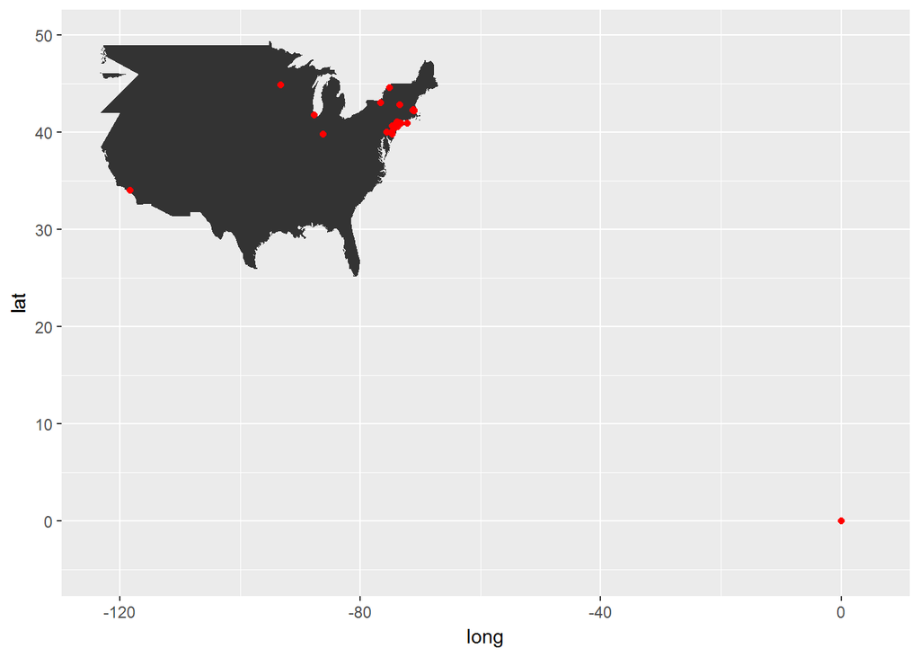

```r
statelines <- map_data("state")
p <- ggplot()
p <- p + geom_polygon(data = statelines, aes(x = long, y = lat, group = group))
p <- p + scale_fill_discrete(guide=FALSE)
p <- p + geom_point(data = traindata, aes(x = longitude, y = latitude), color = "red")
p <- p + scale_x_continuous(limits = c(min(traindata$longitude)-5, max(traindata$longitude)+5))
p <- p + scale_y_continuous(limits = c(min(traindata$latitude)-5, max(traindata$latitude)+5))
plot(p)
```

```r
noll <- traindata$listing_id[which(traindata$latitude <= 40.55 |
                                         traindata$latitude >= 40.95 |
                                         traindata$longitude <= -74.125 |
                                         traindata$longitude >= -73.65)]
traindata$building_id <- as.factor(unlist(traindata$building_id))
unclassified <- traindata[which(traindata$listing_id %in% noll),]
unclassified <- select(unclassified, listing_id, building_id, longitude, latitude)
llb <- data.frame(traindata$listing_id, traindata$building_id)
llb <- llb[-which(llb$traindata.listing_id %in% unclassified$listing_id),]

rm(llb)

traindata$latitude[which(traindata$listing_id %in% unclassified$listing_id)] <- 0
traindata$longitude[which(traindata$listing_id %in% unclassified$listing_id)] <- 0

noll <- testdata$listing_id[which(testdata$latitude <= 40.55 |
                                        testdata$latitude >= 40.95 |
                                        testdata$longitude <= -74.125 |
                                        testdata$longitude >= -73.65)]
testdata$building_id <- as.factor(unlist(testdata$building_id))
unclassified <- testdata[which(testdata$listing_id %in% noll),]
unclassified <- select(unclassified, listing_id, building_id, longitude, latitude)
llb <- data.frame(testdata$listing_id, testdata$building_id)
llb <- llb[-which(llb$testdata.listing_id %in% unclassified$listing_id),]

rm(llb)

testdata$latitude[which(testdata$listing_id %in% unclassified$listing_id)] <- 0
testdata$longitude[which(testdata$listing_id %in% unclassified$listing_id)] <- 0

rm(unclassified); rm(noll)
```

```r
latlonggrid <- data.frame(traindata$listing_id, traindata$longitude, traindata$latitude)
names(latlonggrid) <- c("listing_id", "longitude", "latitude")
minlong <- min(latlonggrid$longitude, na.rm = TRUE); maxlong <- max(latlonggrid$longitude[latlonggrid$longitude < 0], na.rm = TRUE)
minlat <- min(latlonggrid$latitude[latlonggrid$latitude > 0], na.rm = TRUE); maxlat <- max(latlonggrid$latitude, na.rm = TRUE)
lat_segment <- (maxlat - minlat)/10
long_segment <- (maxlong - minlong)/10
latlonggrid$longcat <- ""
latlonggrid$latcat <- ""

catlong <- function(x) {
      as.character((maxlong - x) %/% long_segment)
}
catlat <- function(y) {
      as.character((maxlat - y) %/% lat_segment)
}
latlonggrid$longcat <- sapply(latlonggrid$longitude, catlong)
latlonggrid$latcat <- sapply(latlonggrid$latitude, catlat)
latlonggrid$longcat[latlonggrid$longcat == "-1749"] <- "unclassified"
latlonggrid$latcat[as.numeric(latlonggrid$latcat) == "1188"] <- "unclassified"
latlonggrid$gridcode <- paste(latlonggrid$longcat, latlonggrid$latcat, sep = "")
latlonggrid$gridcode <- gsub("^unclassifiedunclassified$", "unclassified", latlonggrid$gridcode)
traindata$longcat <- as.factor(latlonggrid$longcat)
traindata$latcat <- as.factor(latlonggrid$latcat)
traindata$gridcode <- as.factor(latlonggrid$gridcode)

latlonggrid <- data.frame(testdata$listing_id, testdata$longitude, testdata$latitude)
names(latlonggrid) <- c("listing_id", "longitude", "latitude")
minlong <- min(latlonggrid$longitude, na.rm = TRUE); maxlong <- max(latlonggrid$longitude[latlonggrid$longitude < 0], na.rm = TRUE)
minlat <- min(latlonggrid$latitude[latlonggrid$latitude > 0], na.rm = TRUE); maxlat <- max(latlonggrid$latitude, na.rm = TRUE)
lat_segment <- (maxlat - minlat)/10
long_segment <- (maxlong - minlong)/10
latlonggrid$longcat <- ""
latlonggrid$latcat <- ""
latlonggrid$longcat <- sapply(latlonggrid$longitude, catlong)
latlonggrid$latcat <- sapply(latlonggrid$latitude, catlat)
latlonggrid$longcat[latlonggrid$longcat == "-1740"] <- "unclassified"
latlonggrid$latcat[as.numeric(latlonggrid$latcat) == "1042"] <- "unclassified"
latlonggrid$gridcode <- paste(latlonggrid$longcat, latlonggrid$latcat, sep = "")
latlonggrid$gridcode <- gsub("^unclassifiedunclassified$", "unclassified", latlonggrid$gridcode)
testdata$longcat <- as.factor(latlonggrid$longcat)
testdata$latcat <- as.factor(latlonggrid$latcat)
testdata$gridcode <- as.factor(latlonggrid$gridcode)

testdata$gridcode <- gsub("010|06|105|11|27|83|84|86|87|97", "unclassified", testdata$gridcode)

rm(lat_segment); rm(long_segment); rm(maxlat); rm(maxlong); rm(minlat); rm(minlong)
rm(latlonggrid)
```

Creating scaled per bedroom and per bathroom cost features

```r
traindata$bedcostindex <- log((as.numeric(traindata$price)/(as.numeric(traindata$bedrooms) + 1)))
traindata$bathcostindex <- log(traindata$price/(traindata$bathrooms + 1))
traindata$bedbathindex <- log(traindata$price/(traindata$bathrooms + traindata$bedrooms + 1))
traindata$bedbathsum <- traindata$bathrooms + traindata$bedrooms

testdata$bedcostindex <- log((as.numeric(testdata$price)/(as.numeric(testdata$bedrooms) + 1)))
testdata$bathcostindex <- log(testdata$price/(testdata$bathrooms + 1))
testdata$bedbathindex <- log(testdata$price/(testdata$bathrooms + testdata$bedrooms + 1))
testdata$bedbathsum <- testdata$bathrooms + testdata$bedrooms
```

Using a shapiro-test to determine whether pricing follows a normal distribution

```r
hist(traindata$price, breaks = 10000, xlim = range(0, 50000))
sprice <- sample(traindata$price, 5000)
shapiro.test(sprice)
rm(sprice)
```

```r
detach(package:plyr)
bb <- data.frame(traindata$listing_id, traindata$building_id, traindata$bedrooms, traindata$price)
names(bb) <- c("listing_id", "building_id", "bedrooms", "price")
bb <- group_by(bb, building_id)
bbstats <- summarize(bb, mean(price), sqrt(var(price)))
names(bbstats) <- c("building_id", "mean", "sd")
bbstats <- sqldf("SELECT bb.listing_id, bb.building_id, bb.price, bbstats.mean, bbstats.sd
                 FROM bb, bbstats
                 WHERE bb.building_id = bbstats.building_id")
zscore <- function(obs, avg, sd) {
      z <- (obs - avg)/sd
      return(z)
}
traindata$zscorepricebuilding <- zscore(bbstats$price, bbstats$mean, bbstats$sd)
traindata$zscorepricebuilding[is.na(traindata$zscorepricebuilding)] <- 0

bb <- data.frame(testdata$listing_id, testdata$building_id, testdata$bedrooms, testdata$price)
names(bb) <- c("listing_id", "building_id", "bedrooms", "price")
bb <- group_by(bb, building_id)
bbstats <- summarize(bb, mean(price), sqrt(var(price)))
names(bbstats) <- c("building_id", "mean", "sd")
bbstats <- sqldf("SELECT bb.listing_id, bb.building_id, bb.price, bbstats.mean, bbstats.sd
                 FROM bb, bbstats
                 WHERE bb.building_id = bbstats.building_id")

testdata$zscorepricebuilding <- zscore(bbstats$price, bbstats$mean, bbstats$sd)
testdata$zscorepricebuilding[is.na(testdata$zscorepricebuilding)] <- 0

rm(bb); rm(bbstats)

high <- function(id) {
      length(which(traindata$interest_level == "high" & traindata$building_id == id))/length(which(traindata$building_id == id))
}
medium <- function(id) {
      length(which(traindata$interest_level == "medium" & traindata$building_id == id))/length(which(traindata$building_id == id))
}
low <- function(id) {
      length(which(traindata$interest_level == "low" & traindata$building_id == id))/length(which(traindata$building_id == id))
}

manno <- function(id) {
      log(length(which(traindata$building_id == id)))
}

bid <- as.data.frame(matrix(data = NA, nrow = length(unique(traindata$building_id)), ncol = 5))
names(bid) <- c("id", "high", "med", "low", "conf")
bid$id <- unique(traindata$building_id)
bid$high <- sapply(bid$id, high)
bid$med <- sapply(bid$id, medium)
bid$low <- sapply(bid$id, low)
bid$conf <- sapply(bid$id, manno)

traindata <- merge(traindata,
                   bid,
                   by.x = "building_id",
                   by.y = "id",
                   all.x = TRUE)

testdata <- merge(testdata,
                  bid,
                  by.x = "building_id",
                  by.y = "id",
                  all.x = TRUE)

testdata$low[is.na(testdata$low)] <- mean(traindata$low)
testdata$med[is.na(testdata$med)] <- mean(traindata$med)
testdata$high[is.na(testdata$high)] <- mean(traindata$high)
testdata$conf[is.na(testdata$conf)] <- min(traindata$conf)

traindata <- select(traindata, -building_id)
testdata <- select(testdata, -building_id)

library(plyr)
```

Calculating various listing densities. Creating features that determine local densities of similar listing types based on number of bedrooms and bathrooms.

```r
a1 <- sapply(1:nrow(traindata),
       function(i) length(which(traindata$latitude <= traindata$latitude[i] + 0.005 &
                                  traindata$latitude >= traindata$latitude[i] - 0.005 &
                                  traindata$longitude <= traindata$longitude[i] + 0.005 &
                                  traindata$longitude >= traindata$longitude[i] - 0.005 &
                                  traindata$bathrooms <= traindata$bathrooms[i] + 1 &
                                  traindata$bathrooms >= traindata$bathrooms[i] - 1 &
                                  traindata$bedrooms <= traindata$bedrooms[i] + 1 &
                                  traindata$bedrooms >= traindata$bedrooms[i] - 1)))

a2 <- sapply(1:nrow(traindata),
             function(i) length(which(traindata$latitude <= traindata$latitude[i] + 0.01 &
                                      traindata$latitude >= traindata$latitude[i] - 0.01 &
                                      traindata$longitude <= traindata$longitude[i] + 0.01 &
                                      traindata$longitude >= traindata$longitude[i] - 0.01 &
                                      traindata$bathrooms <= traindata$bathrooms[i] + 1 &
                                      traindata$bathrooms >= traindata$bathrooms[i] - 1 &
                                      traindata$bedrooms <= traindata$bedrooms[i] + 1 &
                                      traindata$bedrooms >= traindata$bedrooms[i] - 1)))

a3 <- sapply(1:nrow(traindata),
             function(i) length(which(traindata$latitude <= traindata$latitude[i] + 0.015 &
                                      traindata$latitude >= traindata$latitude[i] - 0.015 &
                                      traindata$longitude <= traindata$longitude[i] + 0.015 &
                                      traindata$longitude >= traindata$longitude[i] - 0.015 &
                                      traindata$bathrooms <= traindata$bathrooms[i] + 1 &
                                      traindata$bathrooms >= traindata$bathrooms[i] - 1 &
                                      traindata$bedrooms <= traindata$bedrooms[i] + 1 &
                                      traindata$bedrooms >= traindata$bedrooms[i] - 1)))

traindata$localdensity <- a1/a2
traindata$lesslocaldensity <- a1/a3
rm(a1); rm(a2); rm(a3)

traindata$localdensity[traindata$localdensity == "NaN"] <- 0

a1 <- sapply(1:nrow(testdata),
             function(i) length(which(testdata$latitude <= testdata$latitude[i] + 0.005 &
                                            testdata$latitude >= testdata$latitude[i] - 0.005 &
                                            testdata$longitude <= testdata$longitude[i] + 0.005 &
                                            testdata$longitude >= testdata$longitude[i] - 0.005 &
                                            testdata$bathrooms <= testdata$bathrooms[i] + 1 &
                                            testdata$bathrooms >= testdata$bathrooms[i] - 1 &
                                            testdata$bedrooms <= testdata$bedrooms[i] + 1 &
                                            testdata$bedrooms >= testdata$bedrooms[i] - 1)))

a2 <- sapply(1:nrow(testdata),
             function(i) length(which(testdata$latitude <= testdata$latitude[i] + 0.01 &
                                            testdata$latitude >= testdata$latitude[i] - 0.01 &
                                            testdata$longitude <= testdata$longitude[i] + 0.01 &
                                            testdata$longitude >= testdata$longitude[i] - 0.01 &
                                            testdata$bathrooms <= testdata$bathrooms[i] + 1 &
                                            testdata$bathrooms >= testdata$bathrooms[i] - 1 &
                                            testdata$bedrooms <= testdata$bedrooms[i] + 1 &
                                            testdata$bedrooms >= testdata$bedrooms[i] - 1)))

a3 <- sapply(1:nrow(testdata),
             function(i) length(which(testdata$latitude <= testdata$latitude[i] + 0.015 &
                                            testdata$latitude >= testdata$latitude[i] - 0.015 &
                                            testdata$longitude <= testdata$longitude[i] + 0.015 &
                                            testdata$longitude >= testdata$longitude[i] - 0.015 &
                                            testdata$bathrooms <= testdata$bathrooms[i] + 1 &
                                            testdata$bathrooms >= testdata$bathrooms[i] - 1 &
                                            testdata$bedrooms <= testdata$bedrooms[i] + 1 &
                                            testdata$bedrooms >= testdata$bedrooms[i] - 1)))

testdata$localdensity <- a1/a2
testdata$lesslocaldensity <- a1/a3
rm(a1); rm(a2); rm(a3)
testdata$localdensity[testdata$localdensity == "NaN"] <- 0
```

Generating features that attempt to isolate the influence of individual managers on rental interest.

```r
high <- function(id) {
      length(which(traindata$interest_level == "high" & traindata$manager_id == id))/length(which(traindata$manager_id == id))
}
medium <- function(id) {
      length(which(traindata$interest_level == "medium" & traindata$manager_id == id))/length(which(traindata$manager_id == id))
}
low <- function(id) {
      length(which(traindata$interest_level == "low" & traindata$manager_id == id))/length(which(traindata$manager_id == id))
}

manno <- function(id) {
      log(length(which(traindata$manager_id == id)))
}

manager <- as.data.frame(matrix(data = NA, nrow = length(unique(traindata$manager_id)), ncol = 5))
names(manager) <- c("id", "high", "med", "low", "conf")
manager$id <- unique(traindata$manager_id)
manager$high <- sapply(manager$id, high)
manager$med <- sapply(manager$id, medium)
manager$low <- sapply(manager$id, low)
manager$conf <- sapply(manager$id, manno)

traindata <- merge(traindata,
                   manager,
                   by.x = "manager_id",
                   by.y = "id",
                   all.x = TRUE)

traindata <- select(traindata, -manager_id)

testdata <- merge(testdata,
                  manager,
                  by.x = "manager_id",
                  by.y = "id",
                  all.x = TRUE)
testdata <- select(testdata, -manager_id)

testdata$low.y[is.na(testdata$low.y)] <- mean(traindata$low.y)
testdata$med.y[is.na(testdata$med.y)] <- mean(traindata$med.y)
testdata$high.y[is.na(testdata$high.y)] <- mean(traindata$high.y)
testdata$conf.y[is.na(testdata$conf.y)] <- min(traindata$conf.y)

rm(manager)
```

Initial analysis of description field. Calculating the character length and the relative frequency of capital letters in each description.

```r
traindata$lengthdesc <- sapply(traindata$description, nchar)
traindata$lengthdesc <- as.numeric(traindata$lengthdesc)
traindata$perccapdesc <- parSapply(cl,
                                   regmatches(
                                         traindata$description,
                                         gregexpr("[A-Z]",
                                                  traindata$description,
                                                  perl=TRUE)),
                                   length)
traindata$perccapdesc <- (as.numeric(traindata$perccapdesc) + 1)/(as.numeric(traindata$lengthdesc) + 1)
traindata$perex <- parSapply(cl, regmatches(
                                          traindata$description,
                                          gregexpr("!",
                                                   traindata$description,
                                                   perl = TRUE)),
                                    length)

testdata$lengthdesc <- sapply(testdata$description, nchar)
testdata$lengthdesc <- as.numeric(testdata$lengthdesc)
testdata$perccapdesc <- parSapply(cl,
                                  regmatches(
                                        testdata$description,
                                        gregexpr("[A-Z]",
                                                 testdata$description,
                                                 perl=TRUE)),
                                  length)
testdata$perccapdesc <- (as.numeric(testdata$perccapdesc) + 1)/(as.numeric(testdata$lengthdesc) + 1)
testdata$perex <- parSapply(cl, regmatches(
                                          testdata$description,
                                          gregexpr("!",
                                              testdata$description,
                                              perl = TRUE)),
                                          length)
```

Sentiment analysis of listing description. Each description is analyzed and quantified based on 8 different emotional sentiments.

```r
traindata$description <- as.character(traindata$description)
sentiment <- as.data.frame(syuzhet::get_sentiment(traindata$description),
                           method = "stanford")
names(sentiment) <- c("sentimentrating")
sentiment$sentimentrating <- scale(sentiment$sentimentrating)
traindata$sentimentrating <- sentiment$sentimentrating
rm(sentiment)
sentiment <- get_nrc_sentiment(traindata$description)
rowsumsentiment <- rowSums(sentiment) + 1
for (i in 1:nrow(sentiment)) {
      sentiment[i,] <- sentiment[i,]/rowsumsentiment[i]
}
sentiment <- as.data.frame(apply(sentiment, 2, scale))
traindata <- data.frame(traindata, sentiment)

testdata$description <- as.character(testdata$description)
sentiment <- as.data.frame(syuzhet::get_sentiment(testdata$description),
                           method = "stanford")
names(sentiment) <- c("sentimentrating")
sentiment$sentimentrating <- scale(sentiment$sentimentrating)
testdata$sentimentrating <- sentiment$sentimentrating
rm(sentiment)
sentiment <- get_nrc_sentiment(testdata$description)
rowsumsentiment <- rowSums(sentiment) + 1
for (i in 1:nrow(sentiment)) {
      sentiment[i,] <- sentiment[i,]/rowsumsentiment[i]
}
sentiment <- as.data.frame(apply(sentiment, 2, scale))
testdata <- data.frame(testdata, sentiment)

rm(sentiment); rm(rowsumsentiment)

traindata <- select(traindata, -description)
testdata <- select(testdata, -description)
```

It should be noted that the image names were found by other Kaggler’s to have a profound effect on listing interest because of an inherent time feature built into the name.

```r
photos <- traindata[,c(9,12)]
names(photos) <- c("link", "num")
photos <- separate(photos,
                   link,
                   into = paste("photonum", 1:max(photos$num), sep = ""),
                   sep = ",")
photos$id <- 1:nrow(photos)
photos <- select(photos, -num)
photos <- gather(data = photos,
                 key = id,
                 value = all,
                 photonum1:photonum68)
photos <- photos[,-2]
photos <- photos[which(photos$all != ""),]
photos <- separate(data = photos,
                   col = all,
                   into = c("listingcode", "photocode"),
                   sep = "_")
length(unique(photos$photocode))

rm(photos)

traindata <- select(traindata, -photos)
testdata <- select(testdata, -photos)
```

Splitting the creation time of the listings to create categorical variables based on month, day, and time of day that each listing was created.

```r
created <- as.data.frame(traindata$created)
names(created) <- c("datetime")
created$datetime <- as.character(created$datetime)
created <- separate(created,
                    col = datetime,
                    into = c("datecreated", "timecreated"),
                    sep = " ")
created$datecreated <- as.Date(created$datecreated)
created$daycreated <- wday(created$datecreated, label=TRUE)
created$month <- month(created$datecreated, label = TRUE)
created$timecreated <- as.numeric(substring(created$timecreated, 1, 2))
created$timeofday <- case_when (
      created$timecreated < 6 ~ "overnight",
      created$timecreated < 12 & created$timecreated >= 6 ~ "morning",
      created$timecreated < 18 & created$timecreated >= 12 ~ "afternoon",
      created$timecreated < 24 & created$timecreated >= 18 ~ "evening"
)
created$dayspassed <- created$datecreated - min(created$datecreated)
created$datecreated <- format(as.Date(created$datecreated, format = "%Y-%m-%d"), "%d")
created$daycreated <- as.factor(as.character(as.factor(created$daycreated)))
created$month <- as.factor(as.character(as.factor(created$month)))
created$timeofday <- as.factor(created$timeofday)
created <- created[,-c(1:2)]
traindata <- data.frame(traindata, created)

created <- as.data.frame(testdata$created)
names(created) <- c("datetime")
created$datetime <- as.character(created$datetime)
created <- separate(created,
                    col = datetime,
                    into = c("datecreated", "timecreated"),
                    sep = " ")
created$datecreated <- as.Date(created$datecreated)
created$daycreated <- wday(created$datecreated, label=TRUE)
created$month <- month(created$datecreated, label = TRUE)
created$timecreated <- as.numeric(substring(created$timecreated, 1, 2))
created$timeofday <- case_when (
      created$timecreated < 6 ~ "overnight",
      created$timecreated < 12 & created$timecreated >= 6 ~ "morning",
      created$timecreated < 18 & created$timecreated >= 12 ~ "afternoon",
      created$timecreated < 24 & created$timecreated >= 18 ~ "evening"
)
created$dayspassed <- created$datecreated - min(created$datecreated)
created$datecreated <- format(as.Date(created$datecreated, format = "%Y-%m-%d"), "%d")
created$daycreated <- as.factor(as.character(as.factor(created$daycreated)))
created$month <- as.factor(as.character(as.factor(created$month)))
created$timeofday <- as.factor(created$timeofday)
created <- created[,-c(1:2)]
testdata <- data.frame(testdata, created)

rm(created)

traindata <- select(traindata, -created)
testdata <- select(testdata, -created)
```

Street and Display Address information and data normalization. Because of the lack in uniformity in which addresses were entered, creating factor variables from each different address would be a computationally difficult task–well beyond the means of my home computer–and likely would prove to be useless. Normalizing the address fields would make that much more feasible. Example: “256 fifth st”, “256 5th ST” and “256 5th str” all represent the same address but would be interpreted as 3 distinct listings before normalizing.

```r
traindata$street_address <- tolower(traindata$street_address)
traindata$display_address <- tolower(traindata$display_address)
traindata$street_address <- trimws(traindata$street_address, which = "both")
traindata$display_address <- trimws(traindata$display_address, which = "both")
traindata$street_address <- gsub(" n |^n ", " north ", traindata$street_address)
traindata$street_address <- gsub(" s |^s ", " south ", traindata$street_address)
traindata$street_address <- gsub(" e |^e ", " east ", traindata$street_address)
traindata$street_address <- gsub(" w |^w ", " west ", traindata$street_address)
traindata$display_address <- gsub(" n |^n ", " north ", traindata$display_address)
traindata$display_address <- gsub(" s |^s ", " south ", traindata$display_address)
traindata$display_address <- gsub(" e |^e ", " east ", traindata$display_address)
traindata$display_address <- gsub(" w |^w ", " west ", traindata$display_address)
traindata$street_address <- trimws(traindata$street_address, which = "both")
traindata$display_address <- trimws(traindata$display_address, which = "both")
traindata$street_address <- gsub("[[:punct:]]", "", traindata$street_address)
traindata$display_address <- gsub("[[:punct:]]", "", traindata$display_address)
traindata$street_address <- gsub(" st$", " street", traindata$street_address)
traindata$street_address <- gsub(" ave$", " avenue", traindata$street_address)
traindata$street_address <- gsub(" pl$", " place", traindata$street_address)
traindata$display_address <- gsub(" st$", " street", traindata$display_address)
traindata$display_address <- gsub(" ave$", " avenue", traindata$display_address)
traindata$display_address <- gsub(" pl$", " place", traindata$display_address)
traindata$street_address <- gsub("1st|first", "1", traindata$street_address)
traindata$street_address <- gsub("2nd|second", "2", traindata$street_address)
traindata$street_address <- gsub("3rd|third", "3", traindata$street_address)
traindata$street_address <- gsub("4th|fourth", "4", traindata$street_address)
traindata$street_address <- gsub("5th|fifth", "5", traindata$street_address)
traindata$street_address <- gsub("6th|sixth", "6", traindata$street_address)
traindata$street_address <- gsub("7th|seventh", "7", traindata$street_address)
traindata$street_address <- gsub("8th|eighth", "8", traindata$street_address)
traindata$street_address <- gsub("9th|ninth", "9", traindata$street_address)
traindata$street_address <- gsub("10th|tenth|ten", "10", traindata$street_address)
traindata$street_address <- gsub("11th|eleventh|eleven", "11", traindata$street_address)
traindata$street_address <- gsub("12th|twelfth|twelve", "12", traindata$street_address)
traindata$street_address <- gsub("13th|thirteenth|thirteen", "13", traindata$street_address)
traindata$street_address <- gsub("0th", "", traindata$street_address)
traindata$street_address <- gsub("  ", " ", traindata$street_address)

traindata$display_address <- gsub("1st|first", "1", traindata$display_address)
traindata$display_address <- gsub("2nd|second", "2", traindata$display_address)
traindata$display_address <- gsub("3rd|third", "3", traindata$display_address)
traindata$display_address <- gsub("4th|fourth", "4", traindata$display_address)
traindata$display_address <- gsub("5th|fifth", "5", traindata$display_address)
traindata$display_address <- gsub("6th|sixth", "6", traindata$display_address)
traindata$display_address <- gsub("7th|seventh", "7", traindata$display_address)
traindata$display_address <- gsub("8th|eighth", "8", traindata$display_address)
traindata$display_address <- gsub("9th|ninth", "9", traindata$display_address)
traindata$display_address <- gsub("10th|tenth|ten", "10", traindata$display_address)
traindata$display_address <- gsub("11th|eleventh|eleven", "11", traindata$display_address)
traindata$display_address <- gsub("12th|twelfth|twelve", "12", traindata$display_address)
traindata$display_address <- gsub("13th|thirteenth|thirteen", "13", traindata$display_address)
traindata$display_address <- gsub("0th", "", traindata$display_address)
traindata$display_address <- gsub("  ", " ", traindata$display_address)

traindata$display_address[which(traindata$display_address == traindata$street_address)] <-
      str_split_fixed(traindata$street_address[which(traindata$display_address == traindata$street_address)], " ", n = 2)[,2]
traindata$display_address[which(traindata$display_address != str_split_fixed(traindata$street_address, " ", n = 2)[,2])] <-
      str_split_fixed(traindata$street_address[which(traindata$display_address != str_split_fixed(traindata$street_address, " ", n = 2)[,2])], " ", n = 2)[,2]
traindata <- select(traindata, -street_address)


testdata$street_address <- tolower(testdata$street_address)
testdata$display_address <- tolower(testdata$display_address)
testdata$street_address <- trimws(testdata$street_address, which = "both")
testdata$display_address <- trimws(testdata$display_address, which = "both")
testdata$street_address <- gsub(" n |^n ", " north ", testdata$street_address)
testdata$street_address <- gsub(" s |^s ", " south ", testdata$street_address)
testdata$street_address <- gsub(" e |^e ", " east ", testdata$street_address)
testdata$street_address <- gsub(" w |^w ", " west ", testdata$street_address)
testdata$display_address <- gsub(" n |^n ", " north ", testdata$display_address)
testdata$display_address <- gsub(" s |^s ", " south ", testdata$display_address)
testdata$display_address <- gsub(" e |^e ", " east ", testdata$display_address)
testdata$display_address <- gsub(" w |^w ", " west ", testdata$display_address)
testdata$street_address <- trimws(testdata$street_address, which = "both")
testdata$display_address <- trimws(testdata$display_address, which = "both")
testdata$street_address <- gsub("[[:punct:]]", "", testdata$street_address)
testdata$display_address <- gsub("[[:punct:]]", "", testdata$display_address)
testdata$street_address <- gsub(" st$", " street", testdata$street_address)
testdata$street_address <- gsub(" ave$", " avenue", testdata$street_address)
testdata$street_address <- gsub(" pl$", " place", testdata$street_address)
testdata$display_address <- gsub(" st$", " street", testdata$display_address)
testdata$display_address <- gsub(" ave$", " avenue", testdata$display_address)
testdata$display_address <- gsub(" pl$", " place", testdata$display_address)
testdata$street_address <- gsub("1st|first", "1", testdata$street_address)
testdata$street_address <- gsub("2nd|second", "2", testdata$street_address)
testdata$street_address <- gsub("3rd|third", "3", testdata$street_address)
testdata$street_address <- gsub("4th|fourth", "4", testdata$street_address)
testdata$street_address <- gsub("5th|fifth", "5", testdata$street_address)
testdata$street_address <- gsub("6th|sixth", "6", testdata$street_address)
testdata$street_address <- gsub("7th|seventh", "7", testdata$street_address)
testdata$street_address <- gsub("8th|eighth", "8", testdata$street_address)
testdata$street_address <- gsub("9th|ninth", "9", testdata$street_address)
testdata$street_address <- gsub("10th|tenth|ten", "10", testdata$street_address)
testdata$street_address <- gsub("11th|eleventh|eleven", "11", testdata$street_address)
testdata$street_address <- gsub("12th|twelfth|twelve", "12", testdata$street_address)
testdata$street_address <- gsub("13th|thirteenth|thirteen", "13", testdata$street_address)
testdata$street_address <- gsub("0th", "", testdata$street_address)
testdata$street_address <- gsub("  ", " ", testdata$street_address)

testdata$display_address <- gsub("1st|first", "1", testdata$display_address)
testdata$display_address <- gsub("2nd|second", "2", testdata$display_address)
testdata$display_address <- gsub("3rd|third", "3", testdata$display_address)
testdata$display_address <- gsub("4th|fourth", "4", testdata$display_address)
testdata$display_address <- gsub("5th|fifth", "5", testdata$display_address)
testdata$display_address <- gsub("6th|sixth", "6", testdata$display_address)
testdata$display_address <- gsub("7th|seventh", "7", testdata$display_address)
testdata$display_address <- gsub("8th|eighth", "8", testdata$display_address)
testdata$display_address <- gsub("9th|ninth", "9", testdata$display_address)
testdata$display_address <- gsub("10th|tenth|ten", "10", testdata$display_address)
testdata$display_address <- gsub("11th|eleventh|eleven", "11", testdata$display_address)
testdata$display_address <- gsub("12th|twelfth|twelve", "12", testdata$display_address)
testdata$display_address <- gsub("13th|thirteenth|thirteen", "13", testdata$display_address)
testdata$display_address <- gsub("0th", "", testdata$display_address)
testdata$display_address <- gsub("  ", " ", testdata$display_address)

testdata$display_address[which(testdata$display_address == testdata$street_address)] <-
      str_split_fixed(testdata$street_address[which(testdata$display_address == testdata$street_address)], " ", n = 2)[,2]
testdata$display_address[which(testdata$display_address != str_split_fixed(testdata$street_address, " ", n = 2)[,2])] <-
      str_split_fixed(testdata$street_address[which(testdata$display_address != str_split_fixed(testdata$street_address, " ", n = 2)[,2])], " ", n = 2)[,2]
testdata <- select(testdata, -street_address)

road <- function(address) {
      nw <- str_count(address, pattern = " ") + 1
      str_split_fixed(address, pattern = " ", n = nw)[nw]
}

traindata$roadtype <- sapply(traindata$display_address, road)
traindata$roadtype <- trimws(traindata$roadtype, which = "both")
traindata$roadtype <- gsub("blvd", "boulevard", traindata$roadtype)
traindata$roadtype <- gsub("pkwy", "parkway", traindata$roadtype)
traindata$roadtype <- gsub("^rd$", "road", traindata$roadtype)
traindata$roadtype <- gsub("^dr$", "drive", traindata$roadtype)
rt <- c("street", "avenue", "place", "boulevard", "parkway", "court", "square", "road", "drive", "lane", "terrace", "broadway", "north", "east", "south", "west", "plaza", "district")
for (i in 1:nrow(traindata)) {
      traindata$roadtype[i] <- ifelse(traindata$roadtype[i] %in% rt, traindata$roadtype[i], "unclassified")
}
traindata$roadtype <- as.factor(traindata$roadtype)

testdata$roadtype <- sapply(testdata$display_address, road)
testdata$roadtype <- trimws(testdata$roadtype, which = "both")
testdata$roadtype <- gsub("blvd", "boulevard", testdata$roadtype)
testdata$roadtype <- gsub("pkwy", "parkway", testdata$roadtype)
testdata$roadtype <- gsub("^rd$", "road", testdata$roadtype)
testdata$roadtype <- gsub("^dr$", "drive", testdata$roadtype)
rt <- c("street", "avenue", "place", "boulevard", "parkway", "court", "square", "road", "drive", "lane", "terrace", "broadway", "north", "east", "south", "west", "plaza", "district")
for (i in 1:nrow(testdata)) {
      testdata$roadtype[i] <- ifelse(testdata$roadtype[i] %in% rt, testdata$roadtype[i], "unclassified")
}
testdata$roadtype <- as.factor(testdata$roadtype)
```

Creating z-score features that relate street address to listing interest.

```r
high <- function(id) {
      length(which(traindata$interest_level == "high" & traindata$display_address == id))/length(which(traindata$display_address == id))
}
medium <- function(id) {
      length(which(traindata$interest_level == "medium" & traindata$display_address == id))/length(which(traindata$display_address == id))
}
low <- function(id) {
      length(which(traindata$interest_level == "low" & traindata$display_address == id))/length(which(traindata$display_address == id))
}

manno <- function(id) {
      log(length(which(traindata$display_address == id)))
}

da <- as.data.frame(matrix(data = NA, nrow = length(unique(traindata$display_address)), ncol = 5))
names(da) <- c("id", "high", "med", "low", "conf")
da$id <- unique(traindata$display_address)
da$high <- sapply(da$id, high)
da$med <- sapply(da$id, medium)
da$low <- sapply(da$id, low)
da$conf <- sapply(da$id, manno)

traindata <- merge(traindata,
                   da,
                   by.x = "display_address",
                   by.y = "id",
                   all.x = TRUE)

testdata <- merge(testdata,
                  da,
                  by.x = "display_address",
                  by.y = "id",
                  all.x = TRUE)

testdata$low[is.na(testdata$low)] <- mean(traindata$low)
testdata$med[is.na(testdata$med)] <- mean(traindata$med)
testdata$high[is.na(testdata$high)] <- mean(traindata$high)
testdata$conf[is.na(testdata$conf)] <- min(traindata$conf)


traindata <- select(traindata ,-display_address)
testdata <- select(testdata ,-display_address)

rm(bid);rm(da)
```

Rearranging fields so that relevant fields are adjacent; a little bit of data science OCD.

```r
traindata <- traindata[,c(7,1:6,8:131)]
testdata <- testdata[,c(7,1:6,8:131)]
```

Identifying factor and numerical features and setting them as such

```r
factorvars <- c(7,127,128,129,130,131)
numvars <- setdiff(c(1:ncol(traindata)), factorvars)

listing_id_test <- testdata$listing_id
traindata$listing_id <- scale(traindata$listing_id)
testdata$listing_id <- scale(testdata$listing_id)

for (i in factorvars) {
      traindata[,i] <- as.factor(traindata[,i])
}

for (i in numvars) {
      traindata[,i] <- as.numeric(traindata[,i])
}

factorvars <- c(127,128,129,130,131)
numvars <- setdiff(c(1:ncol(traindata)), factorvars)

for (i in factorvars) {
      testdata[,i] <- as.factor(testdata[,i])
}

for (i in numvars) {
      testdata[,i] <- as.numeric(testdata[,i])
}
```

Identifying highly correlated features and removing them

```r
corrtrain <- cor(traindata[,numvars])
correlated <- findCorrelation(corrtrain, cutoff = 0.95)
traindata <- traindata[,-correlated]
testdata <- testdata[,-correlated]

rm(corrtrain); rm(correlated); rm(factorvars); rm(i); rm(j); rm(numvars); rm(rt)
```

Creating training model. After several modeling attempts, I settled on a boosted tree model.

```r
set.seed(314)

intrain <- createDataPartition(traindata$interest_level, p = 0.7, list = FALSE)
train_set <- traindata[intrain,]
val_set <- traindata[-intrain,]

xgbtree_grid <- expand.grid(nrounds = c(145, 150, 155),
                            max_depth = 100,
                            eta = 0.30,
                            gamma = 0,
                            colsample_bytree = c(0.55, 0.6, 0.65),
                            min_child_weight = 1,
                            subsample = c(0.9, 1))


tc <- trainControl(method = "cv",
                   number = 10,
                   repeats = 5,
                   classProbs = TRUE)

xgbtree_model <- train(interest_level ~.,
                  data = train_set,
                  method = "xgbTree",
                  trControl = tc,
                  tuneGrid = xgbtree_grid,
                  objective = "multi:softprob",
                  eval_metric = "mlogloss")
```

Generating the testdata predictions in the format that Kaggle requires

```r
prediction_xgb <- predict(xgbtree_model, testdata, type = "prob")
confusionMatrix(prediction_xgb, val_set$interest_level)

xgb_prediction <- cbind(listing_id_test, prediction_xgb)
xgb_prediction <- xgb_prediction[,c(1,2,4,3)]
names(xgb_prediction) <- c("listing_id", "high", "medium", "low")
xgb_prediction[,c(2:4)] <- round(xgb_prediction[,c(2:4)], 6)
```

And writing the prediction file to disk for upload

```r
write.csv(xgb_prediction, "C:/Users/Bryan/Google Drive/Kaggle/TwoSigma/xgb.csv", row.names = FALSE)
```